# Зелимхан Гудиев. Лабораторная №1

Значения, которые являются выбросами для всех переменных:

```r
df <- data.frame(x1, x2, x3, x4)
# rm(x1, x2, x3, x4)
attach(df) # attach позволяет обращаться к переменным x1,x2,x3,x4 дата фрейма df без необходимости указвать наименования дата фрейма x1
```

```r
(a <- which(x1 %in% boxplot.stats(x1)$out))
```

```
## integer(0)
```

```r
(b <- which(x2 %in% boxplot.stats(x2)$out))
```

```
## [1] 71 79 87 97
```

```r
(c <- which(x3 %in% boxplot.stats(x3)$out))
```

```
## integer(0)
```

```r
(d <- which(x3 %in% boxplot.stats(x4)$out))
```

```
## integer(0)
```

```r
detach(df)
```

```r
(outlier.list1 <- Reduce(intersect, list(a, b, c, d)))
```

```
## integer(0)
```

**Ответ:** *В данных отсутствуют значения, которые являются выбросами для всех переменных*

Значения, которые являются выбросом для хотя бы одной переменной:

```r
(outlier.list2 <- Reduce(union, list(a, b, c, d)))
```

```
## [1] 71 79 87 97
```

**Ответ:** *Вышеуказанные строки являются выбросами хотя бы для одной переменной*

Выделите выбросы с помощью кластерного анализа. Напомним, что в кластерном анализе методом К-средних данные группируются на основе близкого расположения к плотным скоплениям. Выбросами, поэтому, будут считаться наблюдения, находящиеся в относительном удалении от таких скоплений. Для выделения выбросов необходимо убрать, при ее наличии, качественную переменную, записав данные под новым именем:

```r
myData2 <- myData[,1:4]
```

Проведите кластеризацию методом К-средних, выделив три кластера:

```r
kmeans.result <- kmeans(myData2, centers = 3)
```

Отобразите центры кластеров:

```r
kmeans.result$centers
```

```
##   SEPALLEN SEPALWID PETALLEN  PETALWID
## 1 5.892063 2.772162 4.337963 1.3841380
## 2 6.773156 3.067851 5.676923 2.0128561
## 3 5.054425 3.388305 1.460417 0.3000434
```

Рассчитайте расстояния от объектов до центров кластеров:

```r
centers <- kmeans.result$centers[kmeans.result$cluster, ]
distances <- sqrt(rowSums((myData2 - centers)^2))
```

Возьмите несколько (например, 5) наибольших получившихся расстояний.

```r
outliers <- order(distances, decreasing=T)[1:5]
print(outliers)
```

```
## [1]  24  89 144  45 120
```

```r
print(myData2[outliers,])
```

```
##     SEPALLEN SEPALWID PETALLEN PETALWID
## 24       7.6      3.0 3.765278 2.100000
## 89       7.7      2.6 6.900000 1.200694
## 144      5.1      3.7 3.765278 0.400000
## 45       7.7      2.8 6.700000 1.200694
## 120      5.1      2.5 3.000000 1.100000
```

Проверьте с помощью графика, можно ли считать эти наблюдения выбросами:

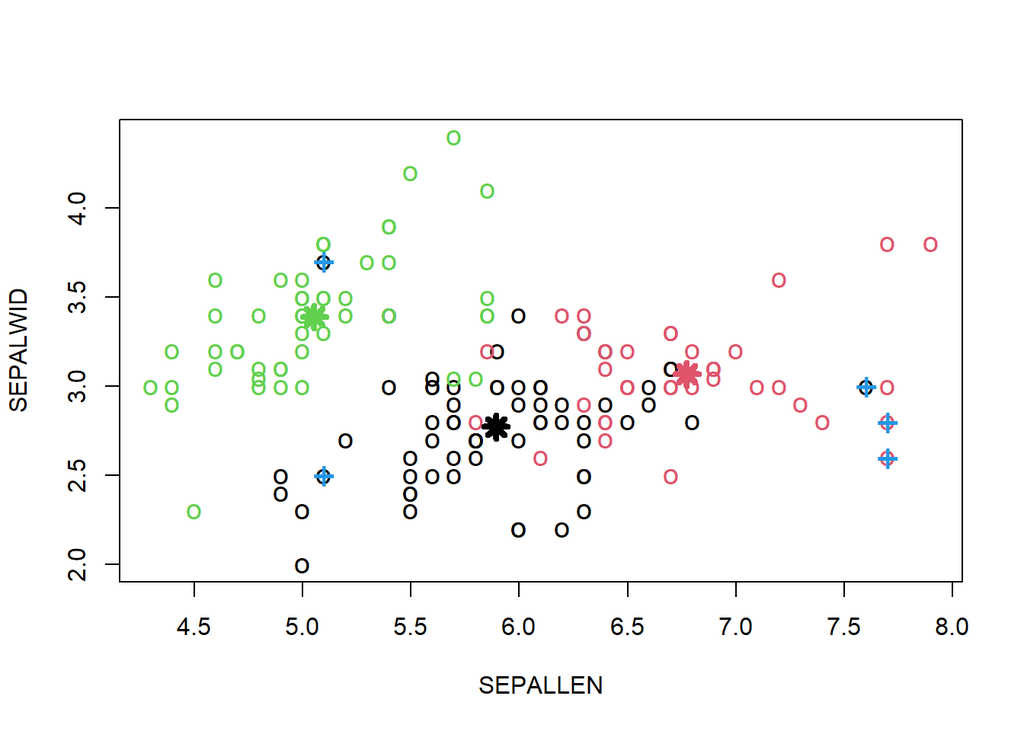

```r
plot(myData2[, c("SEPALLEN", "SEPALWID")], pch = "o", col = kmeans.result$cluster, cex = 1.2)
points(kmeans.result$centers[, c("SEPALLEN", "SEPALWID")], col = 1:3, pch = 8, cex = 1.5, lwd = 4)
points(myData2[outliers, c("SEPALLEN", "SEPALWID")], pch = "+", col = 4, cex = 1.7)
```

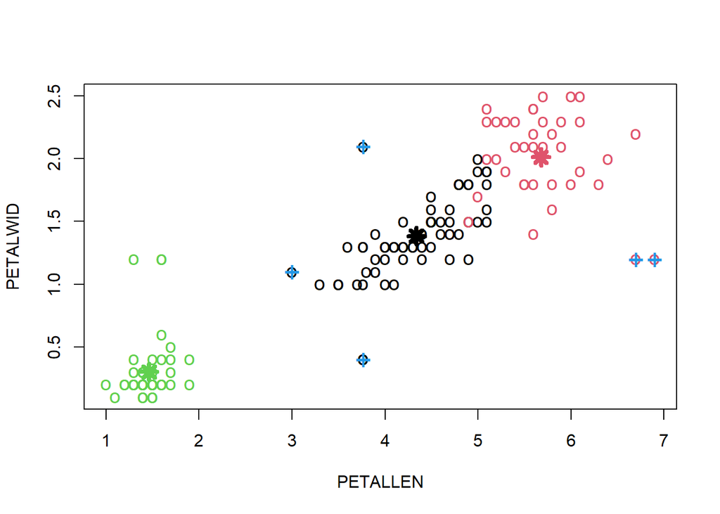

```r
plot(myData2[, c("PETALLEN", "PETALWID")], pch = "o", col = kmeans.result$cluster, cex = 1.2)
points(kmeans.result$centers[, c("PETALLEN", "PETALWID")], col = 1:3, pch = 8, cex = 1.5, lwd = 4)
points(myData2[outliers, c("PETALLEN", "PETALWID")], pch = "+", col = 4, cex = 1.7)
```

**Ответ:**  
*Да, данные наблюедения можно счиать выбросами*

Кратко опишите, какие наблюдения являются аномальными: - только по одной переменной;  
**Ответ:**  
*Выбросами по одной переменной являются строки: 71, 79, 87, 97*

Выдвиньте разумные предположения о том, чем могли быть вызваны эти аномальные значения. Сделайте выводы о том, что, в данном случае, целесообразно предпринять относительно выбросов. **Ответ: выбросы это цветы с экстремальными значениями PETALWID и PETALLEN. Поскольку для наше задачи они не оказывают существенного влияния и их количество не велико, оптимальным решением будет оставить выбросы в выборке.**

Представьте данные в виде: (где y, x1, x2, … – количественные переменные из данных) блочных диаграмм:

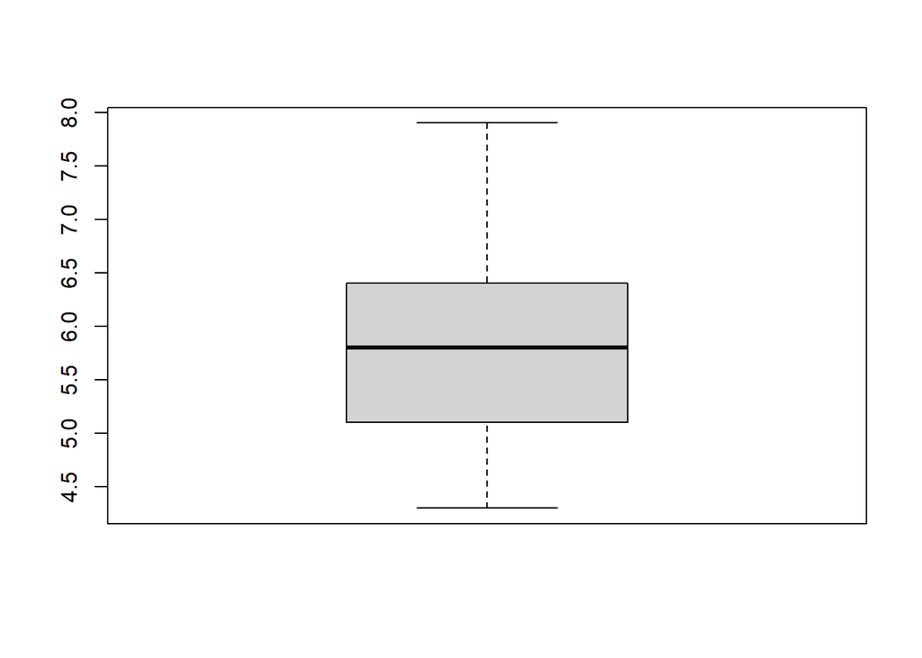

```r
boxplot(x1)
```

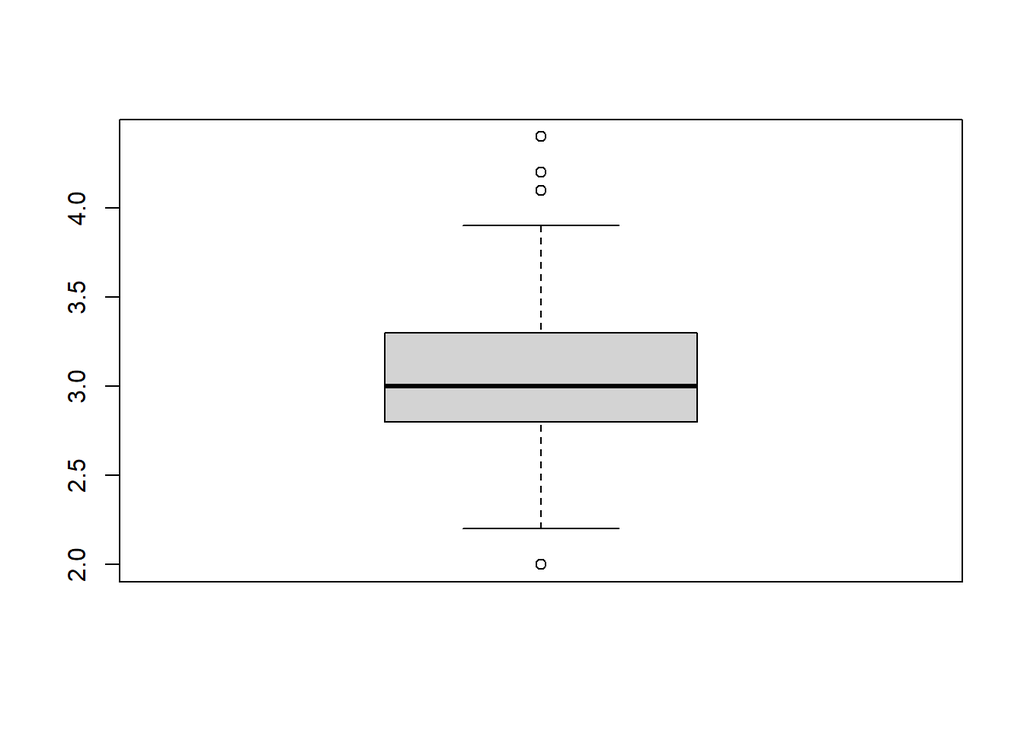

```r
boxplot(x2)
```

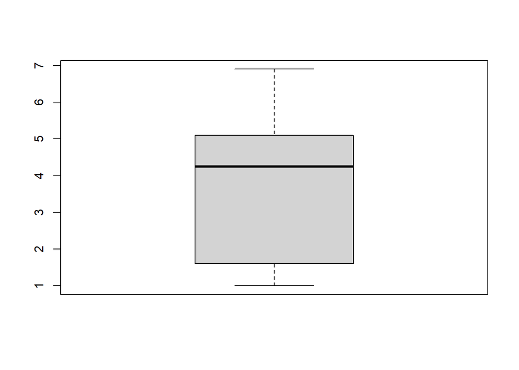

```r
boxplot(x3)
```